# GBSV MC2 – Augmentation

Autor:in

Luca Manna

Veröffentlichungsdatum

28. April 2026

# 1 Aufgabe: Augmentation

**Land:** USA **Semester:** FS26

## 1.1 Tag 1 – Daten & Domäne

### 1.1.1 Anwendungsfall

*Fokus: Domäne und Anwendungskontext*

SET ist ein US-amerikanisches Kartenspiel (1974 von Marsha Falco entwickelt, vertrieben durch Set Enterprises, Fountain Hills, Arizona). Eine Partie läuft visuell: 12 Karten liegen offen auf dem Tisch, alle Spielenden suchen gleichzeitig nach einer gültigen Dreierkombination über die vier Eigenschaften Menge, Farbe, Form und Füllung. Persönliche Motivation: Ich spiele SET regelmässig mit meiner Freundin und verliere dabei konstant. Diese MC soll als Grundbaustein für ein späteres Erkennungsmodell dienen, das aus einem Foto der Auslage automatisch das nächste gültige SET vorschlägt. Dieser Anwendungsfall ist relevant für die USA, da SET dort erfunden wurde, vertrieben wird und im schulischen wie privaten Umfeld breit verankert ist.

### 1.1.2 Problemstellung

*Fokus: technische Schwachstelle*

Dieses Projekt befasst sich mit der robusten Erkennbarkeit von SET-Karten in Smartphone-Fotos einer realen Auslage. Reale Aufnahmen unterliegen photometrischen Störungen (Innenbeleuchtung in unterschiedlichen Farbtemperaturen, Glanzlicht auf der leicht glänzenden Kartenoberfläche, Schatten durch Hände, Sensorrauschen bei wenig Licht) und geometrischen Effekten durch Kamerawinkel und Tischneigung (perspektivische Verzerrung, Verkippung der Karten gegenüber der Bildebene, ungleichmässige Schärfe). Diese Bedingungen verändern die für die Klassifikation der vier Karteneigenschaften relevanten Bildmerkmale. Wird ein Erkennungspfad ausschliesslich auf einem sauberen Referenzbild getestet, bleibt unklar, gegenüber welchen realistischen Störungen er instabil wird. Augmentation erlaubt es, solche Störungen kontrolliert auf das Referenzbild anzuwenden, bevor in späteren Tasks Pattern Detection (Aufgabe 2) und Segmentation (Aufgabe 3) folgen.

### 1.1.3 Experimentelles Ziel

*Fokus: Untersuchungsziel auf konzeptioneller Ebene*

Ziel ist zu untersuchen, wie stark realistische photometrische Störungen die Erkennbarkeit klassifikationsrelevanter Bildstrukturen beeinflussen und unter welchen Bedingungen die fragilste der vier Eigenschaften, die halb-Streifenfüllung, noch zuverlässig vom Original unterscheidbar bleibt.

### 1.1.4 Datendefinition, Quelle und Visualisierung

*Fokus: Datencharakteristik, Datenquelle und visuelle Inspektion*

Das Referenzbild ist eine eigene Smartphone-Aufnahme einer regulären SET-Auslage (`mc2/data/IMG_6947.JPG`, 4032 x 3024 Pixel, RGB, JPG-komprimiert). Es zeigt 12 Karten in 3 x 4 Anordnung auf einer dunkelgrünen Spielmatte und repräsentiert eine zulässige Spielsituation gemäss Spielregeln [1]. Relevante Bildstrukturen sind: Kartenränder (rechteckig mit abgerundeten Ecken, hoher Kantenkontrast zum Untergrund), Symbole (Raute, Balken, Welle in 1-3 Exemplaren), Farbflächen (rot, violett, grün) und Füllungstexturen (leer, halb mit horizontalen Streifen, voll). Bereits im Originalbild sind leichte photometrische Effekte erkennbar (ungleichmässige Innenbeleuchtung, einzelne Glanzlichter, geringe perspektivische Verkippung), die als realistische Ausgangslage für die Augmentation dienen.

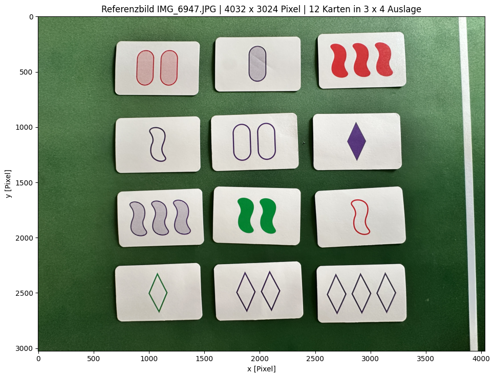

```
Auflösung: 4032 x 3024 Pixel | Kanäle: 3 | dtype: uint8 | Werte: [0, 255]
```

```python
from pathlib import Path

import matplotlib.pyplot as plt
import numpy as np
from PIL import Image

IMG_PATH = Path("..") / "data" / "IMG_6947.JPG"
img = np.array(Image.open(IMG_PATH))
H, W = img.shape[:2]

fig, ax = plt.subplots(figsize=(10, 7.5))
ax.imshow(img)
ax.set_title(
    f"Referenzbild IMG_6947.JPG | {W} x {H} Pixel | 12 Karten in 3 x 4 Auslage"
)
ax.set_xlabel("x [Pixel]")
ax.set_ylabel("y [Pixel]")
plt.tight_layout()
plt.show()

print(
    f"Auflösung: {W} x {H} Pixel | Kanäle: {img.shape[2]} | dtype: {img.dtype} | Werte: [{img.min()}, {img.max()}]"
)
```

### 1.1.5 Identifizierte Bildstruktur

Aus den vier klassifikationsrelevanten Eigenschaften wird die **halb-gefüllte Symbolfläche** ausgewählt, konkret der einzelne violette halb-Balken in der oberen Reihe (mittlere Spalte). Begründung: “Leer” wird durch eine klare Umrisslinie definiert, “voll” durch eine homogene Farbfläche, “halb” hingegen durch eine periodische Streifenstruktur mit geringem lokalem Kontrast. Glanzlicht oder Schatten waschen die Streifen aus und treiben die Klassifikation in Richtung “voll”. Sensorrauschen überlagert die schmale Streifenfrequenz direkt im klassifikationsrelevanten Frequenzbereich. Diese Struktur ist damit das natürliche Stresstest-Element für die Augmentation in Tag 3.

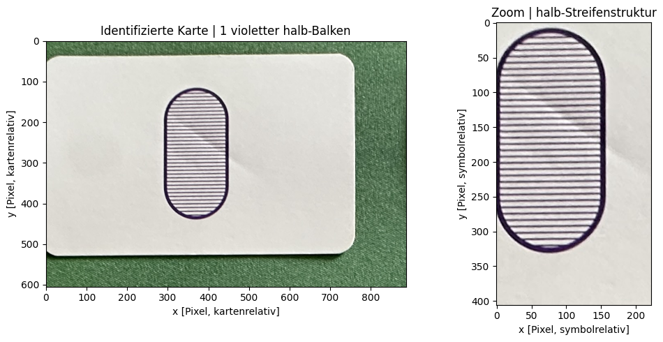

```python
y0, y1 = int(0.05 * H), int(0.25 * H)
x0, x1 = int(0.40 * W), int(0.62 * W)
card_crop = img[y0:y1, x0:x1]

sy0, sy1 = int(card_crop.shape[0] * 0.18), int(card_crop.shape[0] * 0.85)
sx0, sx1 = int(card_crop.shape[1] * 0.33), int(card_crop.shape[1] * 0.58)
symbol_crop = card_crop[sy0:sy1, sx0:sx1]

fig, axes = plt.subplots(1, 2, figsize=(11, 5))
axes[0].imshow(card_crop)
axes[0].set_title("Identifizierte Karte | 1 violetter halb-Balken")
axes[0].set_xlabel("x [Pixel, kartenrelativ]")
axes[0].set_ylabel("y [Pixel, kartenrelativ]")
axes[1].imshow(symbol_crop)
axes[1].set_title("Zoom | halb-Streifenstruktur")
axes[1].set_xlabel("x [Pixel, symbolrelativ]")
axes[1].set_ylabel("y [Pixel, symbolrelativ]")
plt.tight_layout()
plt.show()
```

**Beobachtungen:**

Im Zoom ist die periodische Streifenstruktur klar erkennbar. Bereits im Original zieht sich eine diagonale Helligkeitsvariation durch das Symbol, die das Streifenmuster lokal abschwächt. Damit ist die Empfindlichkeit der Struktur gegenüber photometrischen Störungen schon im Referenzbild sichtbar.

### 1.1.6 Ziel der Augmentation

Ziel ist es, photometrische Aufnahmestörungen einer typischen Smartphone-Heimaufnahme kontrolliert auf das Referenzbild zu übertragen und die Empfindlichkeit der halb-Streifenstruktur quantitativ messbar zu machen. Geometrische Transformationen (Translation, Rotation, Spiegelung) sind laut Aufgabenstellung ausgeschlossen. Konkrete Methoden, Parameter und Konfigurationen folgen an Tag 2.

## 1.2 Tag 2 – Methodisches Design

### 1.2.1 Theoretische Grundlage und Methodenwahl

*Fokus: prinzipienbasierte Begründung im Kontext des Anwendungsfalls*

Diese Untersuchung wendet zwei komplementäre **photometrische Augmentationen** im **Spatial Domain** auf das Referenzbild an. Geometrische Transformationen sind laut Aufgabenstellung ausgeschlossen. Beide gewählten Augmentationen greifen direkt die in Tag 1 identifizierte Schwachstelle an, die periodische Streifenstruktur der halb-Füllung, jedoch auf unterschiedlicher Skala und mit unterschiedlichem physikalischem Mechanismus. Diese Komplementarität ist die methodische Klammer zwischen den beiden Augmentationen und erlaubt in Tag 4 eine saubere Trennung der Effekte.

**Augmentation A: Additives Gauss’sches Sensorrauschen.** Smartphone-Aufnahmen in Innenräumen mit moderater Beleuchtung erzeugen Sensorrauschen, das näherungsweise als pixelweise unabhängige, normalverteilte Störung modelliert wird. Der relevante Effekt für die halb-Streifenstruktur ist ein **frequenzüberlappender Angriff**: das breitbandige Rauschen enthält Energie genau in dem schmalen Frequenzband, in dem auch die periodischen Streifen liegen. Damit verschlechtert sich das Signal-Rausch-Verhältnis im klassifikationsrelevanten Band direkt, ohne den Mittelwert oder die globale Helligkeit zu verändern.

**Augmentation B: Multiplikatives radiales Beleuchtungs-Shading.** Innenbeleuchtung ist räumlich inhomogen (Punktlichtquelle, Vignette des Objektivs, schräger Lichteinfall). Dies wird als langsame multiplikative Modulation der Bildintensität modelliert. Der relevante Effekt für die halb-Streifenstruktur ist eine **Reduktion des lokalen Kontrasts** in den schwächer beleuchteten Bildregionen: Streifen und Streifenzwischenräume werden gemeinsam dunkler skaliert, der absolute Helligkeitsunterschied zwischen ihnen schrumpft. Die Klassifikation wird in Richtung “voll” (homogene Fläche) gedrängt.

Beide Augmentationen werden im Spatial Domain umgesetzt, da die in Tag 1 dokumentierten Aufnahmestörungen physikalisch dort entstehen (Sensor, Beleuchtung) und nicht über eine optische Punktbildfunktion. Eine Frequenzdomänen-Variante (z. B. Tiefpass-Filterung als Defokus-Modell) wäre für diesen Anwendungsfall nicht erste Wahl und wurde nicht aufgenommen.

### 1.2.2 Parameterdefinition und mathematische Spezifikation

*Fokus: explizite Parameterwahl, Herleitung und Einheitenkonsistenz*

Sei $I(x,y,c) \in [0,255]$ das Referenzbild mit Pixelkoordinaten $(x,y)$ und Kanal $c \in \{R,G,B\}$. Sei $W$ die Bildbreite, $H$ die Bildhöhe und $r_{max} = \tfrac{1}{2}\sqrt{W^2 + H^2}$ die maximale Distanz vom Bildzentrum zur Ecke.

**Augmentation A (Sensorrauschen):**

$$I_A(x,y,c) = \mathrm{clip}\!\left(\, I(x,y,c) + n(x,y,c),\; 0,\; 255 \,\right), \quad n(x,y,c) \sim \mathcal{N}(0, \sigma^2)$$

Das Rauschen wird pixel- und kanalweise unabhängig gezogen. Der Seed wird für Reproduzierbarkeit fixiert. Der einzige variierte Parameter ist die Standardabweichung $\sigma$ in Grauwert-Einheiten.

**Augmentation B (radiales Shading):**

$$I_B(x,y,c) = \mathrm{clip}\!\left(\, I(x,y,c) \cdot S(x,y),\; 0,\; 255 \,\right), \quad S(x,y) = 1 - k \cdot \frac{r(x,y)^2}{r_{max}^2}$$

mit $r(x,y) = \sqrt{(x - W/2)^2 + (y - H/2)^2}$ als radiale Distanz vom Bildzentrum. Die Shading-Funktion $S$ ist im Zentrum gleich 1 und fällt zur Ecke hin auf $1-k$ ab. Der einzige variierte Parameter ist die Shading-Tiefe $k$ (dimensionslos).

| Aug | Parameter | Symbol | Werte | Einheit | Herleitung |
| --- | --- | --- | --- | --- | --- |
| A | Rausch-Standardabweichung | $\sigma$ | 5, 15 | Grauwert (8 Bit) | mild $\approx$ Smartphone bei guter Beleuchtung; stark $\approx$ ISO-Reserve nahe Limit |
| B | Shading-Tiefe | $k$ | 0.3, 0.6 | dimensionslos | mild $\approx$ leichte Vignette / weiche Innenbeleuchtung; stark $\approx$ einseitige Punktlichtquelle |

**Quantitatives Mass für Tag 4 (eine einzige Metrik, alle Konfigurationen).** Im halb-Symbol-ROI wird das Bild in Graustufen umgewandelt, das vertikale Intensitätsprofil $p(y) = \tfrac{1}{N_x}\sum_x I_{gray}(x,y)$ gebildet und das 1D-Powerspektrum $P(f)$ per FFT berechnet. Die **spektrale Streifenenergie** $E_{stripe}$ ist die Energie in einem schmalen Frequenzband um den dominanten Streifen-Peak $f_{stripe}$:

$$E_{stripe} = \sum_{|f - f_{stripe}| < \Delta f} P(f)$$

Pro Konfiguration wird $E_{stripe}$ relativ zur Baseline berichtet, $E_{rel} = E_{stripe}^{\,(aug)} / E_{stripe}^{\,(base)}$.

### 1.2.3 Experimentelles Design für die nächsten Tage

| # | Konfiguration | $\sigma$ | $k$ | Erwartung für $E_{rel}$ |
| --- | --- | --- | --- | --- |
| 0 | Baseline (Original) | 0 | 0 | 1.00 (per Definition) |
| 1 | Noise mild | 5 | 0 | leicht erhöht, Streifen visuell erhalten |
| 2 | Noise stark | 15 | 0 | deutlich erhöht im Band, SNR-Verlust |
| 3 | Shading mild | 0 | 0.3 | leicht verringert, lokaler Kontrast abschwächt |
| 4 | Shading stark | 0 | 0.6 | deutlich verringert, Streifenpeak schwach |

### 1.2.4 Methodische Limitationen und Risikofaktoren

Das additive Gauss-Rauschen modelliert thermisches Sensorrauschen idealtypisch. JPEG-Kompressionsartefakte, fixed-pattern noise und nichtlineare Kamerakurven sind nicht abgebildet. Das radiale Shading-Modell ist symmetrisch um das Bildzentrum; reale Innenbeleuchtung ist häufig direktional und erzeugt asymmetrische Helligkeitsabfälle. Beide Augmentationen lassen Glanzlichter explizit aus. Schliesslich wird auf einem einzigen Referenzbild gearbeitet; quantitative Aussagen gelten zunächst nur für diese eine Aufnahme.

## 1.3 Tag 3 – Implementierung

### 1.3.1 Imports, Konstanten und Konfigurationen

```python
from pathlib import Path

import matplotlib.pyplot as plt
import numpy as np
from PIL import Image

# --- Pfade ---
IMG_PATH = Path("..") / "data" / "IMG_6947.JPG"

# --- Augmentations-Parameter ---
SIGMA_MILD = 5
SIGMA_STARK = 15
K_MILD = 0.3
K_STARK = 0.6
SEED = 42

# --- ROI-Koordinaten (relativ, identisch zu Tag 1) ---
CARD_Y0_R, CARD_Y1_R = 0.05, 0.25
CARD_X0_R, CARD_X1_R = 0.40, 0.62
SYM_Y0_R, SYM_Y1_R = 0.18, 0.85
SYM_X0_R, SYM_X1_R = 0.33, 0.58

# --- Alle Konfigurationen ---
CONFIGS = [
    {"label": "Baseline", "sigma": 0, "k": 0.0, "color": "black"},
    {
        "label": f"Noise σ={SIGMA_MILD}",
        "sigma": SIGMA_MILD,
        "k": 0.0,
        "color": "steelblue",
    },
    {
        "label": f"Noise σ={SIGMA_STARK}",
        "sigma": SIGMA_STARK,
        "k": 0.0,
        "color": "royalblue",
    },
    {"label": f"Shading k={K_MILD}", "sigma": 0, "k": K_MILD, "color": "darkorange"},
    {"label": f"Shading k={K_STARK}", "sigma": 0, "k": K_STARK, "color": "saddlebrown"},
]
```

### 1.3.2 Augmentationsfunktionen und Shading-Map

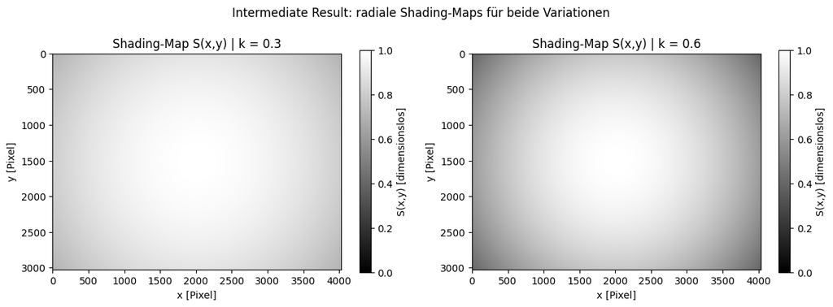

```
Shading-Map | k=0.3: Zentrum=1.000, Ecke=0.700
Shading-Map | k=0.6: Zentrum=1.000, Ecke=0.400
```

```python
def apply_noise(img: np.ndarray, sigma: float, seed: int = SEED) -> np.ndarray:
    rng = np.random.default_rng(seed)
    noise = rng.normal(0, sigma, img.shape)
    return np.clip(img.astype(float) + noise, 0, 255).astype(np.uint8)


def apply_shading(img: np.ndarray, k: float) -> np.ndarray:
    h, w = img.shape[:2]
    cy, cx = h / 2.0, w / 2.0
    r_max = np.sqrt(cx**2 + cy**2)
    ys, xs = np.mgrid[0:h, 0:w]
    r = np.sqrt((xs - cx) ** 2 + (ys - cy) ** 2)
    S = 1.0 - k * (r / r_max) ** 2
    return np.clip(img.astype(float) * S[:, :, np.newaxis], 0, 255).astype(np.uint8)


def apply_config(img: np.ndarray, cfg: dict) -> np.ndarray:
    result = img.copy()
    if cfg["sigma"] > 0:
        result = apply_noise(result, cfg["sigma"])
    if cfg["k"] > 0:
        result = apply_shading(result, cfg["k"])
    return result


# --- Shading-Map als Intermediate Result visualisieren ---
img_ref = np.array(Image.open(IMG_PATH))
H, W = img_ref.shape[:2]
cy, cx = H / 2.0, W / 2.0
r_max = np.sqrt(cx**2 + cy**2)
ys, xs = np.mgrid[0:H, 0:W]
r = np.sqrt((xs - cx) ** 2 + (ys - cy) ** 2)

fig, axes = plt.subplots(1, 2, figsize=(12, 4))
for ax, k_val in zip(axes, [K_MILD, K_STARK]):
    S = 1.0 - k_val * (r / r_max) ** 2
    im = ax.imshow(S, cmap="gray", vmin=0, vmax=1)
    plt.colorbar(im, ax=ax, label="S(x,y) [dimensionslos]")
    ax.set_title(f"Shading-Map S(x,y) | k = {k_val}")
    ax.set_xlabel("x [Pixel]")
    ax.set_ylabel("y [Pixel]")
plt.suptitle("Intermediate Result: radiale Shading-Maps für beide Variationen", y=1.02)
plt.tight_layout()
plt.show()

print(f"Shading-Map | k={K_MILD}: Zentrum={1.0:.3f}, Ecke={1.0 - K_MILD:.3f}")
print(f"Shading-Map | k={K_STARK}: Zentrum={1.0:.3f}, Ecke={1.0 - K_STARK:.3f}")
```

### 1.3.3 Verifikation auf synthetischem Testbild

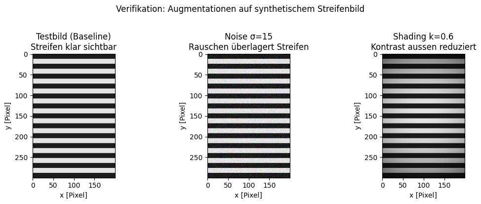

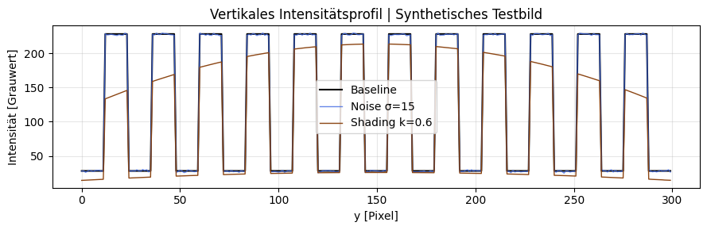

```python
STRIPE_H = 12
TEST_H, TEST_W = 300, 200

row_idx = np.arange(TEST_H)
stripe_vals = ((row_idx // STRIPE_H) % 2) * 200 + 28
test_gray = np.tile(stripe_vals[:, np.newaxis], (1, TEST_W))
test_img = np.stack([test_gray] * 3, axis=2).astype(np.uint8)

test_noise = apply_noise(test_img, SIGMA_STARK)
test_shading = apply_shading(test_img, K_STARK)

fig, axes = plt.subplots(1, 3, figsize=(11, 4))
titles = [
    "Testbild (Baseline)\nStreifen klar sichtbar",
    f"Noise σ={SIGMA_STARK}\nRauschen überlagert Streifen",
    f"Shading k={K_STARK}\nKontrast aussen reduziert",
]
for ax, data, title in zip(axes, [test_img, test_noise, test_shading], titles):
    ax.imshow(data, cmap="gray", vmin=0, vmax=255)
    ax.set_title(title)
    ax.set_xlabel("x [Pixel]")
    ax.set_ylabel("y [Pixel]")
plt.suptitle("Verifikation: Augmentationen auf synthetischem Streifenbild", y=1.02)
plt.tight_layout()
plt.show()

profile_base = test_img[:, :, 0].mean(axis=1)
profile_noise = test_noise[:, :, 0].mean(axis=1)
profile_shading = test_shading[:, :, 0].mean(axis=1)

fig, ax = plt.subplots(figsize=(9, 3))
ax.plot(profile_base, label="Baseline", color="black", linewidth=1.5)
ax.plot(
    profile_noise,
    label=f"Noise σ={SIGMA_STARK}",
    color="royalblue",
    linewidth=1.0,
    alpha=0.8,
)
ax.plot(
    profile_shading, label=f"Shading k={K_STARK}", color="saddlebrown", linewidth=1.0
)
ax.set_xlabel("y [Pixel]")
ax.set_ylabel("Intensität [Grauwert]")
ax.set_title("Vertikales Intensitätsprofil | Synthetisches Testbild")
ax.legend()
ax.grid(True, alpha=0.3)
plt.tight_layout()
plt.show()
```

### 1.3.4 Alle 5 Konfigurationen auf dem Referenzbild

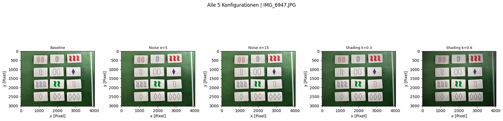

```python
aug_images = [apply_config(img_ref, cfg) for cfg in CONFIGS]

fig, axes = plt.subplots(1, 5, figsize=(18, 5))
for ax, aug, cfg in zip(axes, aug_images, CONFIGS):
    ax.imshow(aug)
    ax.set_title(cfg["label"], fontsize=9)
    ax.set_xlabel("x [Pixel]")
    ax.set_ylabel("y [Pixel]")
plt.suptitle("Alle 5 Konfigurationen | IMG_6947.JPG", y=1.01)
plt.tight_layout()
plt.show()
```

### 1.3.5 ROI-Zoom: halb-Symbol-Crop (alle 5 Konfigurationen)

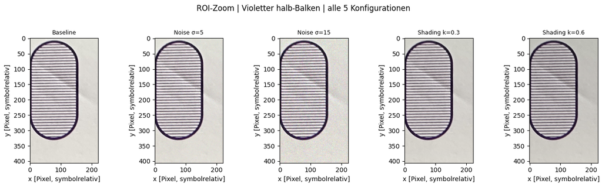

```python
cy0, cy1 = int(CARD_Y0_R * H), int(CARD_Y1_R * H)
cx0, cx1 = int(CARD_X0_R * W), int(CARD_X1_R * W)


def get_symbol_crop(aug_img: np.ndarray) -> np.ndarray:
    card = aug_img[cy0:cy1, cx0:cx1]
    sh, sw = card.shape[:2]
    return card[
        int(SYM_Y0_R * sh) : int(SYM_Y1_R * sh),
        int(SYM_X0_R * sw) : int(SYM_X1_R * sw),
    ]


symbol_crops = [get_symbol_crop(aug) for aug in aug_images]

fig, axes = plt.subplots(1, 5, figsize=(14, 4))
for ax, crop, cfg in zip(axes, symbol_crops, CONFIGS):
    ax.imshow(crop)
    ax.set_title(cfg["label"], fontsize=9)
    ax.set_xlabel("x [Pixel, symbolrelativ]")
    ax.set_ylabel("y [Pixel, symbolrelativ]")
plt.suptitle("ROI-Zoom | Violetter halb-Balken | alle 5 Konfigurationen", y=1.02)
plt.tight_layout()
plt.show()
```

### 1.3.6 Vertikale Intensitätsprofile im Symbol-ROI

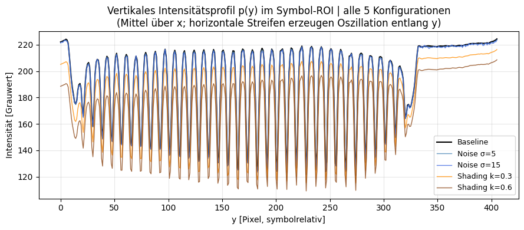

```
Profil-Amplitude (Max - Min) im Symbol-ROI [Grauwert]:
  Baseline            : 103.1
  Noise σ=5           : 102.8
  Noise σ=15          : 102.3
  Shading k=0.3       : 101.1
  Shading k=0.6       : 99.3
```

```python
fig, ax = plt.subplots(figsize=(9, 4))

for crop, cfg in zip(symbol_crops, CONFIGS):
    gray = crop.mean(axis=2)
    profile = gray.mean(axis=1)
    ax.plot(
        profile,
        label=cfg["label"],
        color=cfg["color"],
        linewidth=1.5 if cfg["label"] == "Baseline" else 1.0,
        alpha=1.0 if cfg["label"] == "Baseline" else 0.8,
    )

ax.set_xlabel("y [Pixel, symbolrelativ]")
ax.set_ylabel("Intensität [Grauwert]")
ax.set_title(
    "Vertikales Intensitätsprofil p(y) im Symbol-ROI | alle 5 Konfigurationen\n"
    "(Mittel über x; horizontale Streifen erzeugen Oszillation entlang y)"
)
ax.legend(fontsize=9)
ax.grid(True, alpha=0.3)
plt.tight_layout()
plt.show()

print("Profil-Amplitude (Max - Min) im Symbol-ROI [Grauwert]:")
for crop, cfg in zip(symbol_crops, CONFIGS):
    profile = crop.mean(axis=2).mean(axis=1)
    print(f"  {cfg['label']:20s}: {profile.max() - profile.min():.1f}")
```

**Beobachtungen:**

## 1.4 Tag 4 – Evaluation

### 1.4.1 Setup: Funktionen und Crops wiederherstellen

```python
from pathlib import Path

import matplotlib.pyplot as plt
import numpy as np
from PIL import Image

IMG_PATH = Path("..") / "data" / "IMG_6947.JPG"

SIGMA_MILD = 5
SIGMA_STARK = 15
K_MILD = 0.3
K_STARK = 0.6
SEED = 42

CARD_Y0_R, CARD_Y1_R = 0.05, 0.25
CARD_X0_R, CARD_X1_R = 0.40, 0.62
SYM_Y0_R, SYM_Y1_R = 0.18, 0.85
SYM_X0_R, SYM_X1_R = 0.33, 0.58

CONFIGS = [
    {"label": "Baseline", "sigma": 0, "k": 0.0, "color": "black"},
    {
        "label": f"Noise σ={SIGMA_MILD}",
        "sigma": SIGMA_MILD,
        "k": 0.0,
        "color": "steelblue",
    },
    {
        "label": f"Noise σ={SIGMA_STARK}",
        "sigma": SIGMA_STARK,
        "k": 0.0,
        "color": "royalblue",
    },
    {"label": f"Shading k={K_MILD}", "sigma": 0, "k": K_MILD, "color": "darkorange"},
    {"label": f"Shading k={K_STARK}", "sigma": 0, "k": K_STARK, "color": "saddlebrown"},
]


def apply_noise(img: np.ndarray, sigma: float, seed: int = SEED) -> np.ndarray:
    rng = np.random.default_rng(seed)
    noise = rng.normal(0, sigma, img.shape)
    return np.clip(img.astype(float) + noise, 0, 255).astype(np.uint8)


def apply_shading(img: np.ndarray, k: float) -> np.ndarray:
    h, w = img.shape[:2]
    cy, cx = h / 2.0, w / 2.0
    r_max = np.sqrt(cx**2 + cy**2)
    ys, xs = np.mgrid[0:h, 0:w]
    r = np.sqrt((xs - cx) ** 2 + (ys - cy) ** 2)
    S = 1.0 - k * (r / r_max) ** 2
    return np.clip(img.astype(float) * S[:, :, np.newaxis], 0, 255).astype(np.uint8)


def apply_config(img: np.ndarray, cfg: dict) -> np.ndarray:
    result = img.copy()
    if cfg["sigma"] > 0:
        result = apply_noise(result, cfg["sigma"])
    if cfg["k"] > 0:
        result = apply_shading(result, cfg["k"])
    return result


img_ref = np.array(Image.open(IMG_PATH))
H, W = img_ref.shape[:2]
cy0, cy1 = int(CARD_Y0_R * H), int(CARD_Y1_R * H)
cx0, cx1 = int(CARD_X0_R * W), int(CARD_X1_R * W)


def get_symbol_crop(aug_img: np.ndarray) -> np.ndarray:
    card = aug_img[cy0:cy1, cx0:cx1]
    sh, sw = card.shape[:2]
    return card[
        int(SYM_Y0_R * sh) : int(SYM_Y1_R * sh),
        int(SYM_X0_R * sw) : int(SYM_X1_R * sw),
    ]


aug_images = [apply_config(img_ref, cfg) for cfg in CONFIGS]
symbol_crops = [get_symbol_crop(aug) for aug in aug_images]
print(
    f"Symbol-Crop Grösse: {symbol_crops[0].shape[1]} x {symbol_crops[0].shape[0]} Pixel (B x H)"
)
```

```
Symbol-Crop Grösse: 222 x 406 Pixel (B x H)
```

### 1.4.2 Baseline-Spektrum und f_stripe bestimmen

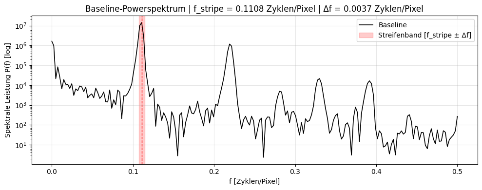

```
f_stripe  = 0.1108 Zyklen/Pixel
Δf        = 0.0037 Zyklen/Pixel (±1.5 FFT-Bins)
Periode   = 9.0 Pixel/Streifen
Bins im Band: 3
```

```python
def compute_spectrum(crop: np.ndarray) -> tuple:
    gray = crop.mean(axis=2)  # RGB -> Grauwert (Mittelwert)
    p = gray.mean(axis=1)  # p(y): Mittel über x pro Zeile
    p_centered = p - p.mean()  # DC entfernen
    window = np.hanning(len(p_centered))
    P = np.abs(np.fft.rfft(p_centered * window)) ** 2
    f = np.fft.rfftfreq(len(p_centered))  # Einheit: Zyklen/Pixel
    return f, P


# Baseline-Spektrum berechnen
f, P_base = compute_spectrum(symbol_crops[0])

# f_stripe: stärkster Peak, Trend-Komponenten ausschliessen (f < F_MIN)
F_MIN = 0.01  # Zyklen/Pixel
search_mask = f > F_MIN
f_stripe = f[search_mask][np.argmax(P_base[search_mask])]
df = f[1] - f[0]  # FFT-Bin-Breite
DELTA_F = 1.5 * df  # Bandbreite: ±1.5 Bins

band_mask = np.abs(f - f_stripe) <= DELTA_F

fig, ax = plt.subplots(figsize=(10, 4))
ax.semilogy(f, P_base, color="black", linewidth=1.2, label="Baseline")
ax.axvspan(
    f_stripe - DELTA_F,
    f_stripe + DELTA_F,
    alpha=0.2,
    color="red",
    label=f"Streifenband [f_stripe ± Δf]",
)
ax.axvline(f_stripe, color="red", linewidth=1.0, linestyle="--")
ax.set_xlabel("f [Zyklen/Pixel]")
ax.set_ylabel("Spektrale Leistung P(f) [log]")
ax.set_title(
    f"Baseline-Powerspektrum | f_stripe = {f_stripe:.4f} Zyklen/Pixel"
    f" | Δf = {DELTA_F:.4f} Zyklen/Pixel"
)
ax.legend()
ax.grid(True, alpha=0.3)
plt.tight_layout()
plt.show()

stripe_period_px = 1.0 / f_stripe if f_stripe > 0 else float("inf")
print(f"f_stripe  = {f_stripe:.4f} Zyklen/Pixel")
print(f"Δf        = {DELTA_F:.4f} Zyklen/Pixel (±1.5 FFT-Bins)")
print(f"Periode   = {stripe_period_px:.1f} Pixel/Streifen")
print(f"Bins im Band: {band_mask.sum()}")
```

### 1.4.3 Spektrale Streifenenergie E_stripe für alle 5 Konfigurationen

```python
results = []
for crop, cfg in zip(symbol_crops, CONFIGS):
    _, P = compute_spectrum(crop)
    E = float(P[band_mask].sum())
    results.append({**cfg, "E_stripe": E})

E_base = results[0]["E_stripe"]
for res in results:
    res["E_rel"] = res["E_stripe"] / E_base

print(f"{'Config':<22} {'E_stripe':>14} {'E_rel':>8}")
print("-" * 48)
for res in results:
    print(f"  {res['label']:<20} {res['E_stripe']:>14.2f} {res['E_rel']:>8.3f}")
```

```
Config                       E_stripe    E_rel
------------------------------------------------
  Baseline                27122802.87    1.000
  Noise σ=5               27089583.62    0.999
  Noise σ=15              26772914.76    0.987
  Shading k=0.3           24318031.42    0.897
  Shading k=0.6           21669018.66    0.799
```

### 1.4.4 Powerspektren aller 5 Konfigurationen

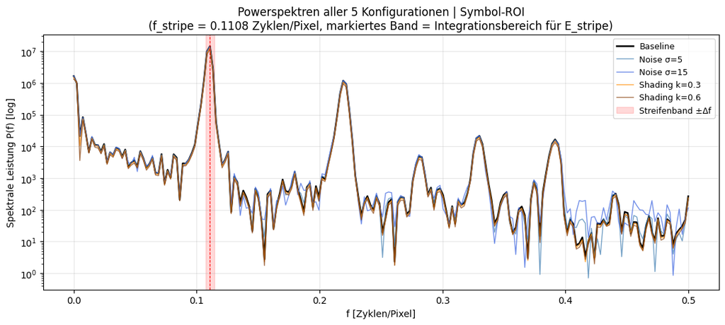

```python
fig, ax = plt.subplots(figsize=(11, 5))

for crop, cfg in zip(symbol_crops, CONFIGS):
    f_i, P_i = compute_spectrum(crop)
    ax.semilogy(
        f_i,
        P_i,
        color=cfg["color"],
        linewidth=1.8 if cfg["label"] == "Baseline" else 1.0,
        alpha=1.0 if cfg["label"] == "Baseline" else 0.75,
        label=cfg["label"],
    )

ax.axvspan(
    f_stripe - DELTA_F,
    f_stripe + DELTA_F,
    alpha=0.15,
    color="red",
    label=f"Streifenband ±Δf",
)
ax.axvline(f_stripe, color="red", linewidth=0.8, linestyle="--")
ax.set_xlabel("f [Zyklen/Pixel]")
ax.set_ylabel("Spektrale Leistung P(f) [log]")
ax.set_title(
    "Powerspektren aller 5 Konfigurationen | Symbol-ROI\n"
    f"(f_stripe = {f_stripe:.4f} Zyklen/Pixel, markiertes Band = Integrationsbereich für E_stripe)"
)
ax.legend(fontsize=9)
ax.grid(True, alpha=0.3)
plt.tight_layout()
plt.show()
```

### 1.4.5 Vergleichstabelle und Interpretation

```python
import pandas as pd

df_results = pd.DataFrame(
    [
        {
            "Konfiguration": r["label"],
            "σ": r["sigma"],
            "k": r["k"],
            "E_stripe": round(r["E_stripe"], 1),
            "E_rel": round(r["E_rel"], 3),
        }
        for r in results
    ]
)
print(df_results.to_string(index=False))
```

```
Konfiguration  σ   k   E_stripe  E_rel
     Baseline  0 0.0 27122802.9  1.000
    Noise σ=5  5 0.0 27089583.6  0.999
   Noise σ=15 15 0.0 26772914.8  0.987
Shading k=0.3  0 0.3 24318031.4  0.897
Shading k=0.6  0 0.6 21669018.7  0.799
```

**Beobachtungen:**

Die Shading-Ergebnisse bestätigen die Erwartung aus Tag 2 klar: $E_{rel}$ sinkt monoton mit zunehmendem $k$ (−10.3 % bei $k=0.3$, −20.1 % bei $k=0.6$). Die multiplikative Abschwächung reduziert den physikalischen Kontrast zwischen Streifen und Streifenzwischenräumen direkt und senkt damit den Streifenpeak absolut.

Die Noise-Ergebnisse weichen von der Erwartung ab: statt eines Anstiegs bleibt $E_{rel}$ nahezu konstant (−0.1 % bei $\sigma=5$, −1.3 % bei $\sigma=15$). Der Grund liegt im Berechnungsweg: das Profil $p(y)$ ist der Mittelwert über $N_x = 222$ Spalten. Additives Rauschen mit $\sigma$ pro Pixel mittelt sich im Profil auf eine Standardabweichung von $\sigma / \sqrt{N_x} = 15 / \sqrt{222} \approx 1.0$ Graustufen pro Zeile – ein vernachlässigbarer Beitrag gegenüber dem Streifensignal. Die Metrik $E_{rel}$ ist damit **robust gegenüber additivem Rauschen**, aber **sensitiv gegenüber multiplikativem Shading**. Diese Asymmetrie war in Tag 2 nicht vorhergesehen und wird in Tag 5 diskutiert.

## 1.5 Tag 5 – Analyse & Kommunikation

# 2 Quellenverzeichnis

[1] Set Enterprises, Inc., “SET - Spielregeln,” Fountain Hills, Arizona, USA. Lokale Kopie: `mc2/data/spielregeln/Spielregeln.md`.